# Nestedness of urban communities

> Nestedness is a measure of structure in an ecological system. There are different measures for nestedness. One common measure is calculating the temperature. We will use that measure to calculate nestedness here. The value ranges from 0-100 where 0 stands for perfectly nested community and 100 stands for random community

```r
library(dplyr)
library(tidyverse)
library(factoextra)
library(densityClust)
library(stats)
library(sf)
library(ggpubr)
library(grid)
library(vegan)
library(phytools)
library(picante)
rm(list = ls())
```

```r
col_loc = read_csv('./bigquery_export__columbidae_birdlife_urban_locations.csv')
head(col_loc)
```

| city_id | city_name | species_name | season_code | present_in_city |
| --- | --- | --- | --- | --- |
| 1 | Honolulu | Spilopelia chinensis | 1 | FALSE |
| 514 | Cali | Columbina passerina | 1 | FALSE |
| 514 | Cali | Columbina talpacoti | 1 | TRUE |
| 514 | Cali | Geotrygon montana | 1 | FALSE |
| 514 | Cali | Paraclaravis mondetoura | 1 | FALSE |
| 514 | Cali | Leptotila plumbeiceps | 1 | FALSE |

```r
species_city_presence = pivot_wider(distinct(col_loc[,c('city_id', 'species_name', 'present_in_city')]), names_from = species_name, values_from = "present_in_city", values_fill = list(present_in_city = F))
species_city_presence = tibble::column_to_rownames(species_city_presence, var='city_id')
species_city_presence
```

|  | Spilopelia chinensis | Columbina passerina | Columbina talpacoti | Geotrygon montana | Paraclaravis mondetoura | Leptotila plumbeiceps | Leptotila verreauxi | Patagioenas albilinea | Patagioenas cayennensis | Patagioenas subvinacea | Zenaida auriculata | Zentrygon frenata | Zenaida macroura | Columba livia | Spilopelia senegalensis | Streptopelia decaocto | Streptopelia tranquebarica | Treron phoenicopterus | Spilopelia suratensis | Columba oenas | Columba palumbus | Patagioenas fasciata | Claravis pretiosa | Paraclaravis geoffroyi | Columbina minuta | Columbina squammata | Leptotila rufaxilla | Patagioenas picazuro | Patagioenas plumbea | … |
| --- | --- | --- | --- | --- | --- | --- | --- | --- | --- | --- | --- | --- | --- | --- | --- | --- | --- | --- | --- | --- | --- | --- | --- | --- | --- | --- | --- | --- | --- | --- |
| 1 | FALSE | FALSE | FALSE | FALSE | FALSE | FALSE | FALSE | FALSE | FALSE | FALSE | FALSE | FALSE | FALSE | FALSE | FALSE | FALSE | FALSE | FALSE | FALSE | FALSE | FALSE | FALSE | FALSE | FALSE | FALSE | FALSE | FALSE | FALSE | FALSE | … |
| 514 | FALSE | FALSE | TRUE | FALSE | FALSE | FALSE | FALSE | FALSE | FALSE | FALSE | TRUE | FALSE | FALSE | FALSE | FALSE | FALSE | FALSE | FALSE | FALSE | FALSE | FALSE | FALSE | FALSE | FALSE | FALSE | FALSE | FALSE | FALSE | FALSE | … |
| 1027 | FALSE | FALSE | FALSE | FALSE | FALSE | FALSE | FALSE | FALSE | FALSE | FALSE | FALSE | FALSE | TRUE | FALSE | FALSE | FALSE | FALSE | FALSE | FALSE | FALSE | FALSE | FALSE | FALSE | FALSE | FALSE | FALSE | FALSE | FALSE | FALSE | … |
| 4355 | FALSE | FALSE | FALSE | FALSE | FALSE | FALSE | FALSE | FALSE | FALSE | FALSE | FALSE | FALSE | FALSE | TRUE | FALSE | FALSE | FALSE | FALSE | FALSE | FALSE | FALSE | FALSE | FALSE | FALSE | FALSE | FALSE | FALSE | FALSE | FALSE | … |
| 6660 | FALSE | FALSE | FALSE | FALSE | FALSE | FALSE | FALSE | FALSE | FALSE | FALSE | FALSE | FALSE | FALSE | TRUE | FALSE | TRUE | FALSE | TRUE | FALSE | FALSE | FALSE | FALSE | FALSE | FALSE | FALSE | FALSE | FALSE | FALSE | FALSE | … |
| 2054 | FALSE | FALSE | FALSE | FALSE | FALSE | FALSE | FALSE | FALSE | FALSE | FALSE | FALSE | FALSE | FALSE | TRUE | FALSE | TRUE | FALSE | FALSE | FALSE | TRUE | TRUE | FALSE | FALSE | FALSE | FALSE | FALSE | FALSE | FALSE | FALSE | … |
| 4358 | FALSE | FALSE | FALSE | FALSE | FALSE | FALSE | FALSE | FALSE | FALSE | FALSE | FALSE | FALSE | FALSE | TRUE | FALSE | TRUE | FALSE | FALSE | FALSE | FALSE | FALSE | FALSE | FALSE | FALSE | FALSE | FALSE | FALSE | FALSE | FALSE | … |
| 5894 | FALSE | FALSE | FALSE | FALSE | FALSE | FALSE | FALSE | FALSE | FALSE | FALSE | FALSE | FALSE | FALSE | FALSE | FALSE | TRUE | FALSE | FALSE | FALSE | FALSE | FALSE | FALSE | FALSE | FALSE | FALSE | FALSE | FALSE | FALSE | FALSE | … |
| 775 | FALSE | FALSE | FALSE | FALSE | FALSE | FALSE | FALSE | FALSE | FALSE | FALSE | FALSE | FALSE | TRUE | FALSE | FALSE | FALSE | FALSE | FALSE | FALSE | FALSE | FALSE | FALSE | FALSE | FALSE | FALSE | FALSE | FALSE | FALSE | FALSE | … |
| 3079 | FALSE | FALSE | FALSE | FALSE | FALSE | FALSE | FALSE | FALSE | FALSE | FALSE | FALSE | FALSE | FALSE | TRUE | FALSE | TRUE | FALSE | FALSE | FALSE | FALSE | TRUE | FALSE | FALSE | FALSE | FALSE | FALSE | FALSE | FALSE | FALSE | … |

[output cut: 500 more lines]

> Function nestedtemp finds the matrix temperature which is defined as the sum of “surprises” in arranged matrix. In arranged unsurprising matrix all species within proportion given by matrix fill are in the upper left corner of the matrix, and the surprise of the absence or presences is the diagonal distance from the fill line (Atmar & Patterson 1993). Function tries to pack species and sites to a low temperature (Rodríguez-Gironés & Santamaria 2006), but this is an iterative procedure, and the temperatures usually vary among runs. Function nestedtemp also has a plot method which can display either incidences or temperatures of the surprises. Matrix temperature was rather vaguely described (Atmar & Patterson 1993), but Rodríguez-Gironés & Santamaria (2006) are more explicit and their description is used here. However, the results probably differ from other implementations, and users should be cautious in interpreting the results. The details of calculations are explained in the vignette Design decisions and implementation that you can read using functions browseVignettes. Function nestedness in the bipartite package is a direct port of the BINMATNEST programme of Rodríguez-Gironés & Santamaria (2006).

> The plots for nestedness temperature is given by these plots. Darker the colour means higher the probability of the species extinction from the site.

```r
temp <- nestedtemp(species_city_presence)
temp
```

```
nestedness temperature: 0.06807224
with matrix fill 0.0124601
```

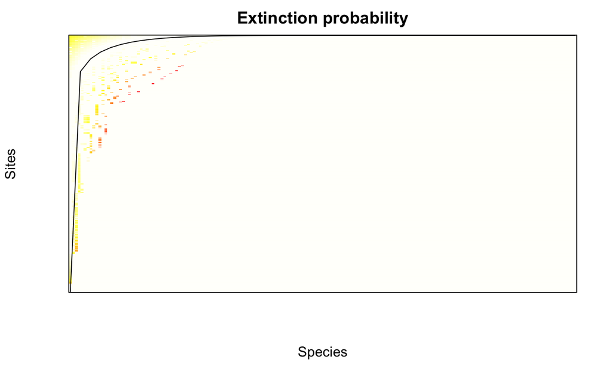

```r
plot(temp, xlab = "Species", ylab="Sites",main="Extinction probability")
```

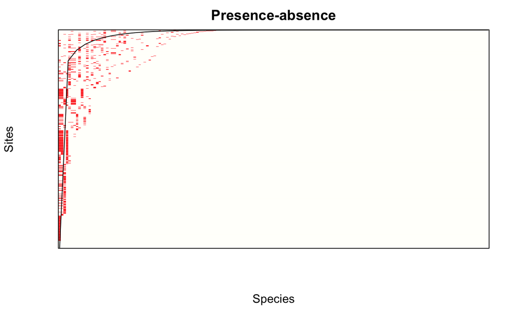

```r
plot(temp, kind="incidence",xlab = "Species", ylab="Sites",main="Presence-absence")
```

```r
jpeg("./outputs/nestedness.jpg", width = 778, height=512)
plot(temp, kind="incidence",xlab = "Species", ylab="Sites",main="Presence-absence")
dev.off()
```

> Function nestedchecker gives the number of checkerboard units, or 2x2 submatrices where both species occur once but on different sites (Stone & Roberts 1990).

```r
nestedchecker(species_city_presence)
```

```
Checkerboard Units    : 424761
C-score (species mean): 28.88352
```

> The nestedness functions evaluate alternative indices of nestedness. The functions are intended to be used together with Null model communities and used as an argument in oecosimu to analyse the non-randomness of results.

```r
oecosimu(species_city_presence, nestedtemp, "quasiswap")
```

```
oecosimu object

Call: oecosimu(comm = species_city_presence, nestfun = nestedtemp, method = "quasiswap")

nullmodel method ‘quasiswap’ with 99 simulations

alternative hypothesis: statistic is less or greater than simulated values

nestedness temperature: 0.06787519
with matrix fill 0.0124601

            statistic     SES     mean     2.5%      50%  97.5% Pr(sim.)
temperature  0.067875 -10.108 0.106958 0.099961 0.107016 0.1147     0.01 **
---
Signif. codes:  0 ‘***’ 0.001 ‘**’ 0.01 ‘*’ 0.05 ‘.’ 0.1 ‘ ’ 1
```

```r
oecosimu(species_city_presence, nestedchecker, "quasiswap")
```

```
oecosimu object

Call: oecosimu(comm = species_city_presence, nestfun = nestedchecker, method = "quasiswap")

nullmodel method ‘quasiswap’ with 99 simulations

alternative hypothesis: statistic is less or greater than simulated values

Checkerboard Units    : 424761
C-score (species mean): 28.88352

              statistic    SES   mean   2.5%    50%  97.5% Pr(sim.)
checkerboards    424761 26.809 376636 373562 376726 379666     0.01 **
---
Signif. codes:  0 ‘***’ 0.001 ‘**’ 0.01 ‘*’ 0.05 ‘.’ 0.1 ‘ ’ 1
```

[output not shown]